# Vehicle-Pedestrian Accidents in Montgomery County

## An analysis of accidents from 2015-2023

##### By Aryan Anwar, Kurumi Sato, and Joshua Muthii

## Introduction

Using the data science pipeline, we were able to explore vehicle-pedestrian accidents within the Montgomery County area in Maryland. This is a topic that should interest anybody living in the DMV area as it could provide great insight as to what conditions make accidents more likely as well as locations within the county that are more susceptible to accidents. We aim to use data science principles and techniques to investigate traffic violations in an attempt to create a model that could potentially predict accidents and successfully pick out areas of concern for pedestrians. In doing so, we expect that this model will give us insight into what features of an area, pedestrian, or motor-vehicle-operator most heavily contribute to an unsafe situation

## Why does this matter?

Additionally, the impact of these accidents are big as some accidents cause serious injury and can even be fatal. Interestingly, the number of car accidents on the road has decreased in the last few years dropping from 50,000 car accidents in 2018 to 40,000 in 2022 but the fatalities in car crashes have actually increased. According to the [Maryland Vehicle Association](https://zerodeathsmd.gov/resources/crashdata/), the number of deaths increased from 512 to 655 over those 5 years. This means that even though there are less people on the road causing fewer accidents the reckless and dangerous behavior of drivers is still a continued problem which can lead to fatal accidents.

In case you would like to do more reading on the behaviors that can increase risks of vehicle accidents, we have added links below that can help!

- https://www.ncbi.nlm.nih.gov/pmc/articles/PMC10802962/
- https://crashstats.nhtsa.dot.gov/Api/Public/ViewPublication/813369
- https://www.sciencedirect.com/science/article/abs/pii/0001457583900192

### Imports

```python
import os
import requests as r
import warnings
import datetime
import numpy as np
warnings.filterwarnings('ignore')
import pandas as pd
import seaborn as sns
import matplotlib.pyplot as plt
import warnings
import re
from sklearn.preprocessing import StandardScaler
from sklearn.linear_model import LogisticRegression
from sklearn.model_selection import train_test_split
from factor_analyzer import FactorAnalyzer
```

## Data Collection

At this stage in the data science cycle, we will be looking through different datasets that can be useful to determine how dangerous each road is for a pedestrian. The data sets we're using are specific to Montgomery County and contain data that involves pedestrian injuries/fatalities. There are many data points offered by the county, such as exact location, road names, vehicle make, weather, surface condition, collision type, traffic violations, drug/alcohol use, and more. All of these factors are important and can provide different reasons as to why the accident may have occurred. This can be determined by analyzing the data. As college students, drug/alcohol use is interesting information to obtain. For elderly drivers, the time of day and weather may be a bigger factor in the causes of a car accident.

This data is collected through a downloaded CSV file that is in the same directory as the .ipynb file for our Jupyter Notebook. We gathered this data directly from the official [Montgomery County population database](https://data.montgomerycountymd.gov/). Thankfully this site contains many datasets relating to civilian safety when it comes to traffic violations. The data is also in a similar format, so all related data pulled from this site can easily be combined, barring some minor adjustments for features that may be present in one data set and not another.

### Retrieving Data From Local CSV File

```python
# Acessing downloaded data
# Data is stored in a local CSV file in the same directory as the Jupyter Notebook file


# Retrieving information on all driving crashes and traffic violations in the area
for file in os.listdir('./drivers'):
    if file.endswith(".csv"):
        drivers_df= pd.read_csv("./drivers/"+file, low_memory= False)
# Receiving information on pedestrian-related crashes and violations
for file in os.listdir('./non_motorists/'):
    if file.endswith(".csv"):
       pedestrian_df =pd.read_csv("./non_motorists/"+file, low_memory = False)
```

### Set up any auxiliary functions

First, to make the data easier to work with we'll create a function to separate the date/time columns of each dataset into date and time columns. This will be easier for us to work with when trying to work on two sets of data as it will be in the same time period. Additionally, this will allow for greater control in specifying how accurate we want to get with time information in our analysis of the data set. We also added another function to standardize_time, for the sake of making sure that the data sets account for data gathered within the same year, we'll create a function to standardize the years of the data sets!

```python
def define_date_and_time (df):

    date_column = df["Crash Date/Time"].map(lambda x: x.date())
    time_column = df["Crash Date/Time"].map(lambda x: x.time())
    temp_df= df.drop(["Crash Date/Time"], axis = 1)
    temp_df["date"]= date_column
    temp_df["time"]= time_column
    return temp_df
```

```python
# Takes in a list of dataframs --> each of which should have a column named "date" which
# contains information about the year, month and day in a datetime object format
def standardize_time(dataframes:list):
    min_year=float('-inf')
    max_year=float('inf')
    for df in dataframes:
        min_year = max(min_year, df["Crash Date/Time"].min().year)
        max_year = min(max_year, df["Crash Date/Time"].max().year)
    return (min_year , max_year)
```

## Data Processing

### Organizing Data in Database

Given the data we want to make sure that the data points match the time they were observed. Here, we make sure to convert time information into datetime objects, and apply a function to standardize the time periods between the two datasets. We want to separate the pedestrian and driver data frame so that it'll be easier to analyze later as most of the time we won't be needing the information at the same time. However, we want to make sure that we use the same duration for the two datasets so we will check that to ensure the maximum and mimumum years of each dataset.

```python
# Make sure that these data sets account for the same time periods
# Turn dates into date time objects before manipulating them
pedestrian_df["Crash Date/Time"] = pd.to_datetime(pedestrian_df["Crash Date/Time"])
drivers_df["Crash Date/Time"] = pd.to_datetime(drivers_df["Crash Date/Time"])

#Make sure datasets refer to the same time period and dates and times are separated in table
min_year, max_year = standardize_time([pedestrian_df, drivers_df])

###
pedestrian_df=  pedestrian_df[pedestrian_df["Crash Date/Time"].dt.year >= min_year]
pedestrian_df=  pedestrian_df[pedestrian_df["Crash Date/Time"].dt.year <= max_year]
drivers_df   =  drivers_df[drivers_df["Crash Date/Time"].dt.year >= min_year]
drivers_df   =  drivers_df[drivers_df["Crash Date/Time"].dt.year <= max_year]
###
# Split the 'Crash Date/Time column into a date column and a time column'
pedestrian_df = define_date_and_time(pedestrian_df)
drivers_df    = define_date_and_time(drivers_df)

# Now our data should reference the same range of year and
# should be organized to better manipulate the time information!
print("Maximum years in datasets is: ",
      pedestrian_df["date"].max().year," : ",
      drivers_df["date"].max().year)
print("Minimum years in dataset is: ",
     pedestrian_df["date"].min().year, " : ",
     drivers_df["date"].min().year)
# Now the data frames should contain information referring to the same range of year
```

```
Maximum years in datasets is:  2023  :  2023
Minimum years in dataset is:  2015  :  2015
```

## Exploratory Analysis & Data Visualialization

Since we now have all of our data we want to try to explore different ways we can analyze all of this data we now have!

#### Gather Data regarding how many vehicle traffic collisions in total happen on a given street

Now, that we have all of our data we want to try to gather information on how many traffic violations happen on each road for the entire 9 years. This will be a cumulative number for each road. We then want to add this number into our dataframe while also renaming some of the columns so they make more sense. We're also only storing important infromation so we drop any columns we may not use

```python
# Gathering information about total motor vehicle accidents that occur on each specific road
drivers_df.dropna(subset = ["Road Name"], inplace = True)
# Collect information about unique streets where accidents have occured
accidents_by_street = drivers_df["Road Name"].value_counts()
# This is the total number of traffic collisions on a given street in the Montgomery Area
accidents_by_street= accidents_by_street.to_dict()
# print(accidents_by_street)
```

```python
# Removing Unneeded Columns

pedestrian_drop_list=["Report Number",
           "Safety Equipment",
           "Location",
           "Pedestrian Visibility",
           "Local Case Number",
           "Off-Road Description",
           "Agency Name",
          "Person ID"]

# pedestrian_df.drop(pedestrian_drop_list, inplace = True, axis = 1)
# pedestrian_df.dropna(subset= ["ACRS Report Type"], inplace = True)
# Only storing information about whether a crash was fatal or not (we don't really need the text)
# It's only ever 'Fatal Crash' or 'Injury Crash'

pedestrian_df["ACRS Report Type"]= (pedestrian_df["ACRS Report Type"]== "Fatal Crash")
pedestrian_df.rename(columns= {"ACRS Report Type": "Fatal"}, inplace = True)
pedestrian_df.rename(columns= {"date": "Date"}, inplace = True)

# Adding information about traffic collisions for each road
pedestrian_df["Total street accidents"]= pedestrian_df["Road Name"].map(lambda x: accidents_by_street.get(x,0))
print() # This is only here to stop it from printing the database
```

### Different conditions

Now that we have totaled some numbers we also want to analyze the data we have now gathered and created. Hopefully, this can give us more insight as to what causes more frequent crashes in Montgomery County. The first feature we looked at was the surface conditions of the road. There are only two main categories, dry and wet surfaces. We then tried to see if the surface condition of the road affected how fatal a crash would be. From a quick glance at the numbers, there isn't a big difference in the severity of the crashes depending on road conditions. In terms of fatal accidents, about 19.17% of fatal accidents happen on wet surfaces while 16.33% of all accidents happen on wet surfaces. There's less than a 3% difference, which is a lot lower than we expected.

```python
# Dry versus wet surface conditions

dry_list = pedestrian_df[pedestrian_df["Surface Condition"] == "DRY"]
wet_list = pedestrian_df[pedestrian_df["Surface Condition"] == "WET"]
print("Dry surfaces: " + str(len(dry_list)))
print("Wet surfaces: " + str(len(wet_list)))
```

```
Dry surfaces: 3520
Wet surfaces: 687
```

```python
# Seperate fatal versus non-fatal information
fatal_accidents_list = pedestrian_df[pedestrian_df["Fatal"] == True]
fatal_dry_list = fatal_accidents_list[fatal_accidents_list["Surface Condition"] == "DRY"]
fatal_wet_list = fatal_accidents_list[fatal_accidents_list["Surface Condition"] == "WET"]
print("Dry surfaces: " + str(len(fatal_dry_list)))
print("Wet surfaces: " + str(len(fatal_wet_list)))
```

```
Dry surfaces: 97
Wet surfaces: 23
```

### Checking how roads in each city affect each city in terms of accidents

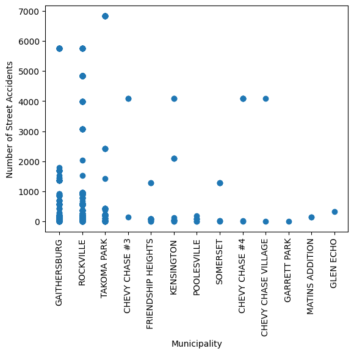

```python
plot_df = pedestrian_df
plot_df.dropna(subset=["Municipality"], inplace = True)
plt.xticks(rotation=90)
plt.plot(plot_df["Municipality"], plot_df["Total street accidents"], marker='o', linestyle='')
plt.xlabel("Municipality")
plt.ylabel("Number of Street Accidents")
```

### Vehicle Make and Model affecting location of crash

To explore other types of data we also checked to see if the vehicle make would affect where an accident might happen. We thought that certain cars would be more likely to be in an accident depending on the average income of the area. However, after maping it out, it seems that majority of the accidents happen in a cluster within a certain area and the make of the car doesn't have a big affect on where the accident occurs

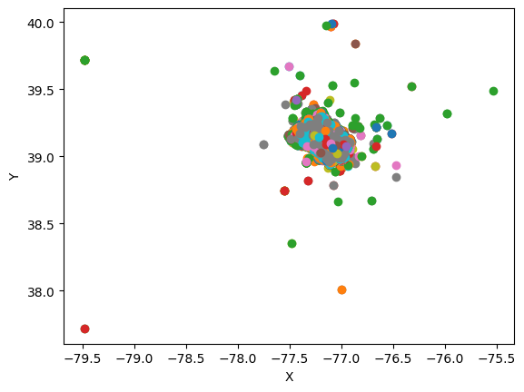

```python
plot_df = drivers_df

# Create dataframe

groups = plot_df.groupby('Vehicle Make')
for name, group in groups:
    plt.plot(group.Longitude, group["Latitude"], marker='o', linestyle='', label=name)

plt.xlabel("X")
plt.ylabel("Y")

# plt.legend(loc="lower right")
plt.show()
```

### Calculating accidents per day

We also calculated the number of accidents per day to see if any of the streets stood out. We also created a dataframe to store accidents per day as that information can be really useful when doing other calculations. We can also see if certain days of the week or months tend to have more accidents. We can also use this data to see if holidays make it less or more likely for an accident to occur. There are many directions we can go with this data!

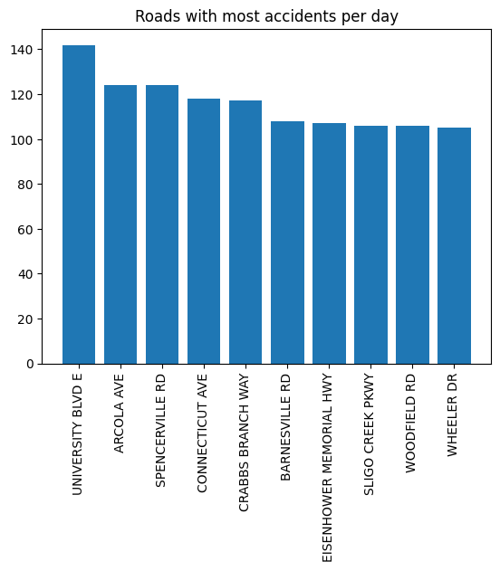

```python
# Gathering information about total motor vehicle accidents that occur on each day
per_day_df = drivers_df

per_day_df.dropna(subset = ["date"], inplace = True)
# Collect information about unique streets where accidents have occurred
per_day_stat = per_day_df["date"].value_counts()

per_day_df["Accidents_per_day"]= per_day_df["date"].map(lambda x: per_day_stat[x])

per_day_df = per_day_df.drop_duplicates(subset=['date'])

per_day_df = per_day_df[per_day_df["Accidents_per_day"] != "NaN"]

plot_df= per_day_df.sort_values("Accidents_per_day", ascending=False).head(10)
plt.title("Roads with most accidents per day")
plt.xticks(rotation=90)
plt.bar(plot_df["Road Name"], plot_df["Accidents_per_day"])
plt.figure(figsize=(10,10))
plt.show()
```

### Vehicle make in each city

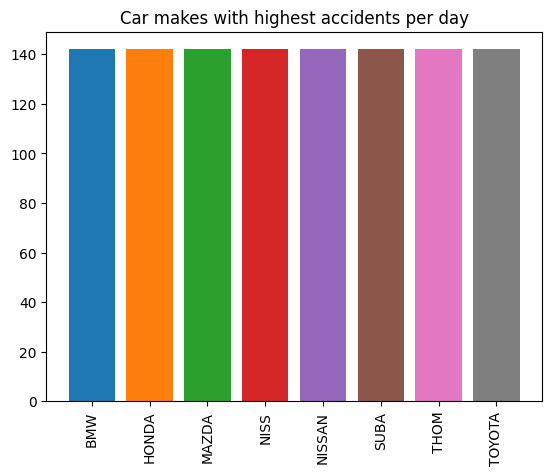

```python
# Check how vehicle type affects each city in terms of accidents!

plot_df= drivers_df.sort_values("Accidents_per_day", ascending=False).head(10)
plt.xticks(rotation=90)

groups = plot_df.groupby("Vehicle Make")


for name, group in groups:
    plt.bar(group['Vehicle Make'], group['Accidents_per_day'], label=name)

# plt.legend(ncol=20, loc='upper left')
plt.title("Car makes with highest accidents per day")
plt.figure(figsize=(10, 8))
plt.show()
```

```python
# Other questions we can maybe look into

# Is the number of accidents increasing per year?

# Are there more accidents during a certain month?

# Try to find this by separating the month and year so it's easier to analyze data later
```

# Logistic Regression

### Model: Analysis, Hypothesis, Testing and Machine Learning

During this phase of the datascience lifecycle, we plan to build hyptheses about which features of a road contribute most to the danger (in this case represented as fatality) for a pedestrian and make predicions based on these features and weights about which roads, during which times, surface conditions, and weather conditions are most likely to contribute to a dangerous scenario for a pedestrian.

Firstly, we isolate the variables which make the most sense to contribute to pedestrian injury/fatality. (For example, leaving out the case identification number) and treat this as a matrix of feature vectors, treating every pedetrian traffic violation as an observation. For categorical values we use a One Hot Encoding to make the data easier to use for our regression analysis.

We then set the Fatality of each observation (a boolean describing whether an accident was fatal) as the true labels corresponding to each incident. Given that we have a binary classification problem and have information regarding the ground truth of each observation, we opted for a Logistic Regression model. With our X and y set, we first apply logistic regression to our data set and observe the weights of each feature.

```python
# Aryans attempt at logistic regression
pedestrian_df['time_in_minutes'] = pedestrian_df['time'].apply(lambda x: (x.hour*60)+ x.minute)
# Removing unknown variables for weather and surface condition
pedestrian_df = pedestrian_df [pedestrian_df["Weather"]!="UNKNOWN"]
pedestrian_df = pedestrian_df [pedestrian_df["Surface Condition"]!="UNKNOWN"]
pedestrian_df = pedestrian_df[pedestrian_df["Weather"] != "OTHER"]
pedestrian_df = pedestrian_df[pedestrian_df["Surface Condition"] != "OTHER"]


feature_vectors = pedestrian_df[['Latitude', 'Longitude', 'Weather',
                                    'time_in_minutes', 'Surface Condition', 'Total street accidents']]


feature_vectors = pd.get_dummies(feature_vectors, columns=['Weather', 'Surface Condition'])
target = pedestrian_df["Fatal"]
X_train, X_val, y_train, y_val = train_test_split(feature_vectors, target, test_size=0.25, random_state=42)
log_reg = LogisticRegression()


model = log_reg.fit(X_train, y_train)

accuracy = model.score(X_val, y_val)
print("Validation set accuracy:", accuracy)


coefficients = pd.DataFrame({'Variable': X_train.columns, 'Coefficient': model.coef_[0]})
print(coefficients)
```

```
Validation set accuracy: 0.9805194805194806
                  Variable  Coefficient
0                 Latitude     0.070027
1                Longitude     0.080383
2          time_in_minutes    -0.000008
3   Total street accidents     0.000275
4            Weather_CLEAR     0.337386
5           Weather_CLOUDY    -0.048800
6            Weather_FOGGY    -0.020544
7          Weather_RAINING    -1.152275
8     Weather_SEVERE WINDS     0.758698
9             Weather_SNOW    -0.041826
10   Surface Condition_DRY    -0.810191
11   Surface Condition_WET    -0.056880
```

Using our model, we can then average out predictions from our observations and associated weights to come to conclusions about which roads tend to be the most dangerous.

```python
predicted_probabilities = model.predict_proba(feature_vectors)[:, 1]
pedestrian_df['Predicted Probability'] = predicted_probabilities

top_5_dangerous_roads = pedestrian_df.groupby('Road Name')['Predicted Probability'].mean().nlargest(5)
print("The top 5 most dangerous roads are:")
for road, probability in top_5_dangerous_roads.items():
    print(f"Road: {road}, Probability: {probability}")
```

```
The top 5 most dangerous roads are:
Road: NEW HAMPSHIRE AVE, Probability: 0.1083096831806501
Road: FREDERICK RD, Probability: 0.0839157997056876
Road: ROCKVILLE PIKE, Probability: 0.0671703430184317
Road: VEIRS MILL RD, Probability: 0.05507702378091756
Road: CONNECTICUT AVE, Probability: 0.05085398658084677
```

## Identifying dangerous roads given weather/surface conditions

Next, using the weights above, we can then apply our model to the different observations in our dataset to acquire information about which roads are more dangerous on average given certain features (such as rainy weather, dry surface conditions etc.). We can then compile a list of the top 3 most dangerous roads given a predetermined set of conditions.

```python
# Identifying most dangerous roads given weather/surface conditions
street_probabilities = pedestrian_df.groupby(['Weather', 'Surface Condition', 'Road Name'])['Predicted Probability'].mean()

for (weather, surface_condition), group in street_probabilities.groupby(['Weather', 'Surface Condition']):
    top_streets = group.nlargest(3)
    print(f"Top streets for {weather} weather and {surface_condition} surface condition:")
    print(top_streets)
    print()
```

```
Top streets for CLEAR weather and DRY surface condition:
Weather  Surface Condition  Road Name
CLEAR    DRY                NEW HAMPSHIRE AVE    0.112583
                            FREDERICK RD         0.086072
                            ROCKVILLE PIKE       0.067966
Name: Predicted Probability, dtype: float64

Top streets for CLEAR weather and WET surface condition:
Weather  Surface Condition  Road Name
CLEAR    WET                FREDERICK RD     0.166527
                            HUNGERFORD DR    0.050407
                            GOSHEN RD        0.047607
Name: Predicted Probability, dtype: float64

Top streets for CLOUDY weather and DRY surface condition:
Weather  Surface Condition  Road Name
CLOUDY   DRY                FREDERICK RD       0.060080
                            ROCKVILLE PIKE     0.046929
                            CONNECTICUT AVE    0.038811
Name: Predicted Probability, dtype: float64

Top streets for CLOUDY weather and WET surface condition:
Weather  Surface Condition  Road Name
CLOUDY   WET                FREDERICK RD         0.119545
                            VEIRS MILL RD        0.077072
                            QUINCE ORCHARD RD    0.038755
Name: Predicted Probability, dtype: float64

Top streets for FOGGY weather and WET surface condition:
Weather  Surface Condition  Road Name
FOGGY    WET                BOOTH ST     0.027895
Name: Predicted Probability, dtype: float64

Top streets for RAINING weather and WET surface condition:
Weather  Surface Condition  Road Name
RAINING  WET                NEW HAMPSHIRE AVE    0.057033
                            FREDERICK RD         0.043099
                            ROCKVILLE PIKE       0.033710
Name: Predicted Probability, dtype: float64

Top streets for SEVERE WINDS weather and DRY surface condition:
Weather       Surface Condition  Road Name
SEVERE WINDS  DRY                ROCKVILLE PIKE    0.099965
Name: Predicted Probability, dtype: float64

Top streets for SNOW weather and WET surface condition:
Weather  Surface Condition  Road Name
SNOW     WET                N SUMMIT AVE    0.028657
                            N HORNERS LA    0.027827
Name: Predicted Probability, dtype: float64
```

## Factor Analysis to identify which combination of factors have the highest impact on fatal accidents

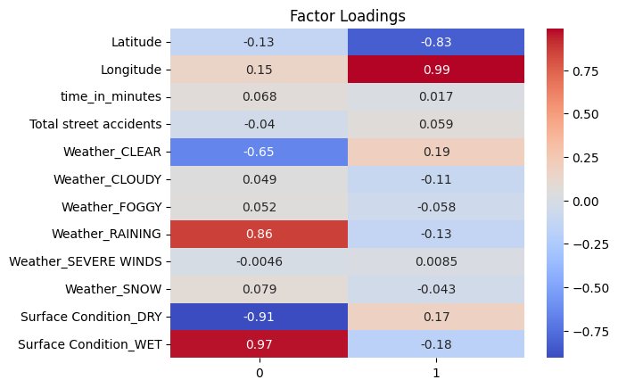

```python
# Factor analysis
scaler = StandardScaler()
scaled_features = scaler.fit_transform(feature_vectors)

fa = FactorAnalyzer(n_factors=2, rotation='varimax')
fa.fit(scaled_features)
loadings = fa.loadings_
loadings_df = pd.DataFrame(loadings, index=feature_vectors.columns)
# print(loadings_df)

sns.heatmap(loadings_df, annot=True, cmap='coolwarm')
plt.title('Factor Loadings')
plt.show()
```

**Factor 0** is dominated by weather and surface conditions. This makes sense because rainy weather and wet surface conditions will lower drivers' visibility and increase the time it takes to break.

# Policy Insight and Conclusion

## Identify Dangerous Streets:

Using the model, we were able to identify which streets are the most dangerous for pedestrians, given different conditions. This identification process involved analyzing historical accident data, weather conditions, time of day, and surface conditions to determine which factors contributed the most to fatal accidents. Our model provides a data-driven approach to point to high-risk areas that require immediate attention.

## Next Steps:

The next step would be to conduct field tests on these roads to identify what makes them so dangerous. Some possible factors that could account for accidents that we could not account for are lighting, potholes, obstructions, construction, poorly designed crossroads, and roads that incline drivers to speed. By understanding these specificities of roads and combining them with weather/condition data, we can understand more thoroughly what causes accidents to happen and work to mitigate these factors.

## Policy Recommendations:

Weather and surface conditions cannot be mitigated, however, their impact can be minimized by implementing some of these recommendations:

1. Enhanced Road Maintenance
2. Improved Lighting
3. Clear Signage
4. Road Redesign
5. Speed Control Measures

## Conclusion:

By leveraging data and field investigations, we can make informed decisions to enhance pedestrian safety. Our model provides a solid framework for identifying high-risk areas, and the insights we can gain from field tests will enable us to address specific risk factors. Through effective policy implementations, we can significantly reduce the incidence of pedestrian accidents and create safer streets for everyone.

### Data Sources:

[Serious and Fatal Pedestrian and Cyclist Collisions (Montgomery County)](https://data.montgomerycountymd.gov/Public-Safety/Crash-Reporting-Non-Motorists-Data/n7fk-dce5/data_preview)  
[Crash Reporting Drivers Data (Montgomery County)](https://data.montgomerycountymd.gov/Public-Safety/Crash-Reporting-Drivers-Data/mmzv-x632/about_data)